# Презентация по лабораторной №7

Анализ файловой системы Linux. Команды для работы с файлами и каталогами

Виноградова М.А

Российский университет дружбы народов, Москва, Россия

29 марта 2025

# Информация

## Докладчик

- Виноградова Мария Андреевна
- студентка НПИбд-01-24
- номер студ. билета 1132240691
- Российский университет дружбы народов
- 1132240691@pfur.ru
- https://github.com/mavinogradova/study_2024-2025_os-intro

## Цель работы

## Выполните все примеры, приведённые в первой части описания лабораторной работы.

### Пример 1

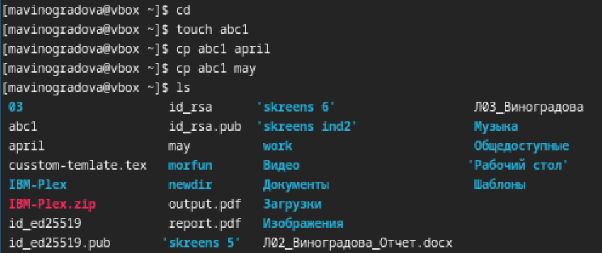

Реализация примера 1

### Пример 2

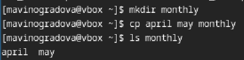

Реализация примера 2

### Пример 3

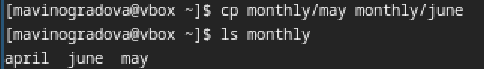

Реализация примера 3

### Пример 4

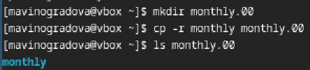

Реализация примера 4

### Пример 5

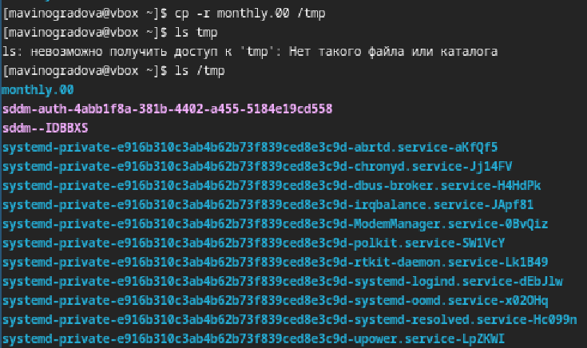

Реализация примера 5

### Пример 6

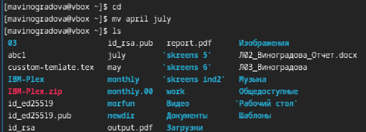

Реализация примера 6

### Пример 7

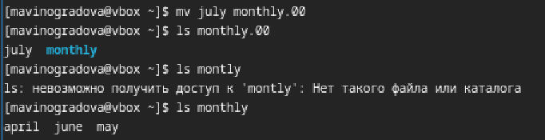

Реализация примера 7

### Пример 8

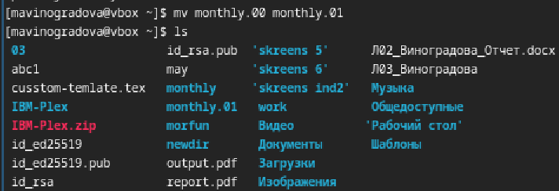

Реализация примера 8

### Пример 9

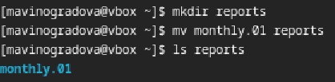

Реализация примера 9

### Пример 10

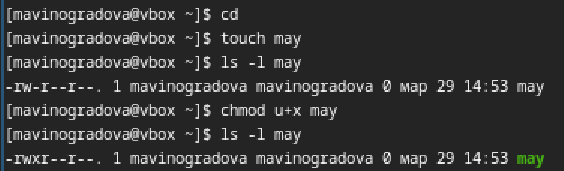

Реализация примера 10

### Пример 11

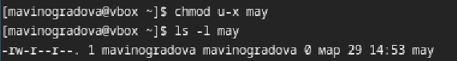

Реализация примера 11

### Пример 12

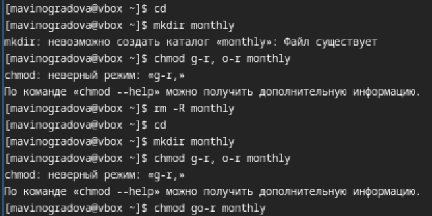

Реализация примера 12

### Пример 13

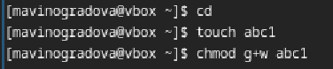

Реализация примера 13

### Пример 14

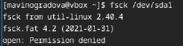

Реализация примера 14

## Выполните следующие действия, зафиксировав в отчёте по лабораторной работе используемые при этом команды и результаты их выполнения:

### Скопируйте файл /usr/include/sys/io.h в домашний каталог и назовите его equipment. Если файла io.h нет, то используйте любой другой файл в каталоге /usr/include/sys/ вместо него.

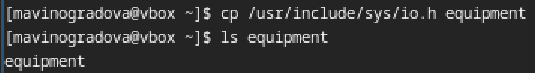

Копируем и называем файл

### Переименуйте файл ~/ski.plases/equipment в ~/ski.plases/equiplist

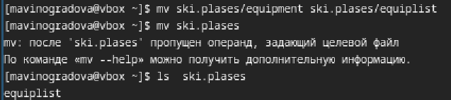

Переименовываем файл

### Создайте в домашнем каталоге файл abc1 и скопируйте его в каталог ~/ski.plases, назовите его equiplist2.

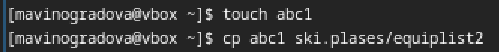

Создаем и копируем файл в каталог

### Переместите файлы ~/ski.plases/equiplist и equiplist2 в каталог ~/ski.plases/equipment.

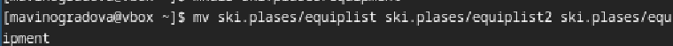

Перемещаем файл в каталог

### Создайте и переместите каталог ~/newdir в каталог ~/ski.plases и назовите его plans.

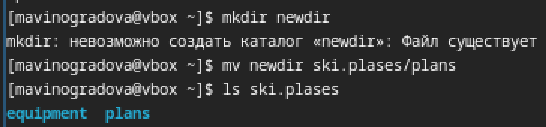

Создаем и перемещаем каталог

## Определите опции команды chmod, необходимые для того, чтобы присвоить перечисленным ниже файлам выделенные права доступа, считая, что в начале таких прав нет:

### Создаем необходимые директории и файлы.

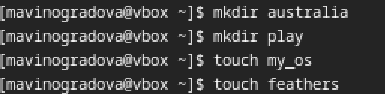

Создаем необходимые директории и файлы

### Присваиваем права доступа.

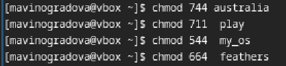

Присваиваем права доступа

### Проверяем правильность присвоенных прав.

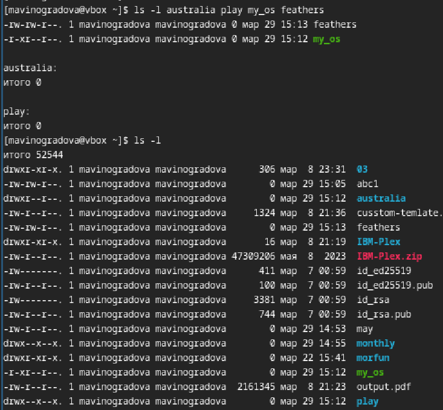

Проверяем

## Проделайте приведённые ниже упражнения, записывая в отчёт по лабораторной работе используемые при этом команды:

### Просмотрите содержимое файла /etc/password.

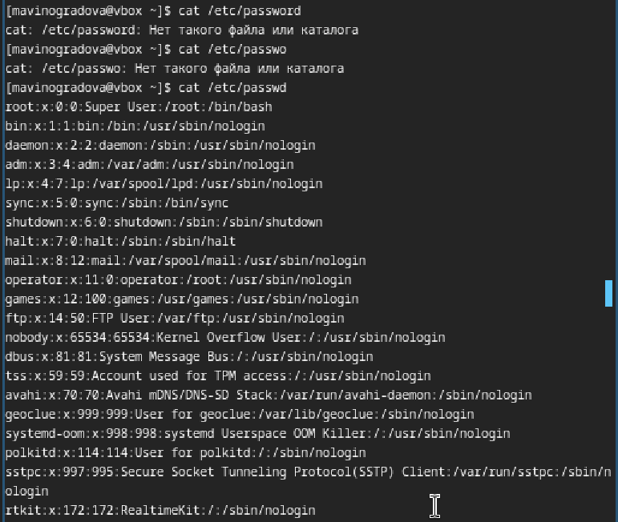

Смотрим содержимое файла

### Что произойдёт, если вы попытаетесь просмотреть файл ~/feathers командой cat?

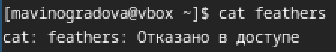

Пробуем просмотреть файл

### Что произойдёт, если вы попытаетесь скопировать файл ~/feathers?

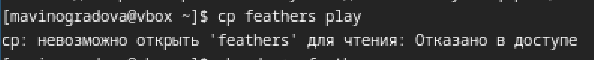

Пробуем скопировать файл

### Перейдите в каталог ~/play. Что произошло?

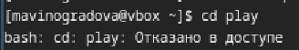

Пробуем перейти в каталог

## Прочитайте man по командам mount, fsck, mkfs, kill и кратко их охарактеризуйте, приведя примеры

### mount.

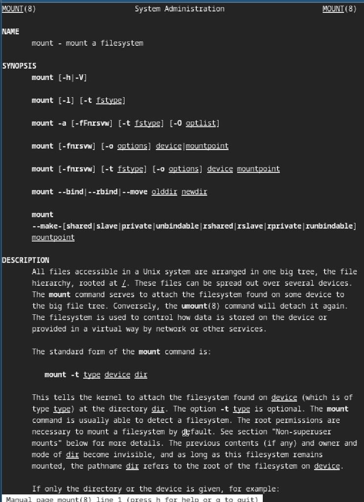

Смотрим информацию о mount

### fsck.

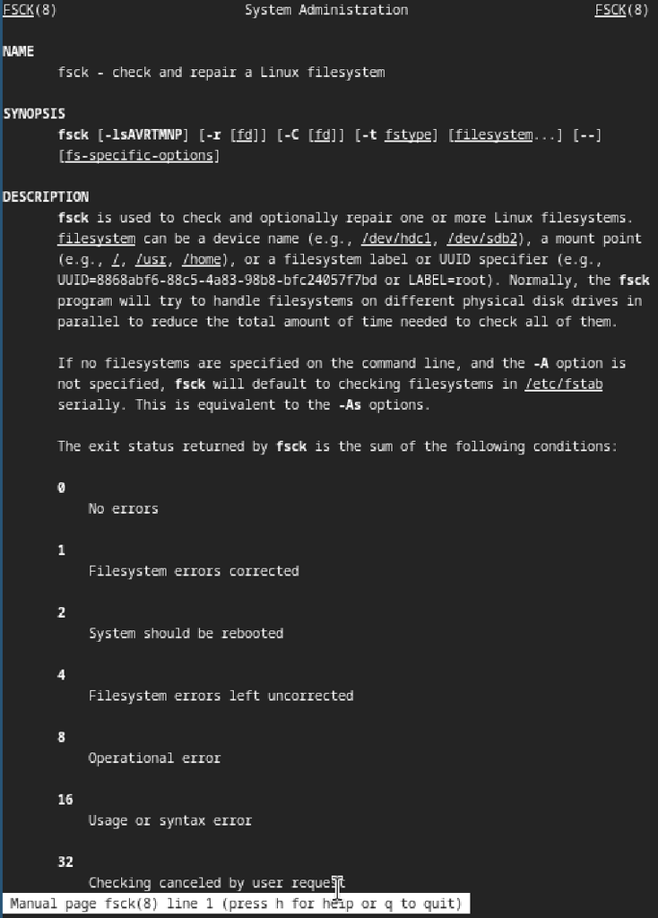

Смотрим информацию о fsck